# Boosting

## Quiz Review

## The Algorithm

1. Use RBS to grow a large tree on full data, stopping when every leaf has a small number of obs.
2. Apply cost-complexity pruning to obtain a best subtree for many values of \(\alpha\).
3. Use k-fold CV to choose \(\alpha\). For each fold:
   - Repeat (1) and (2) on training data.
   - Compute the test MSE on all subtrees (one test MSE per \(\alpha\)). Average the test MSEs for each \(\alpha\) and choose \(\alpha\) that minimizes.
4. Use that \(\alpha\) to select your best subtree in (2)

## Bagging and Random Forests

## Review

### Goal

Decrease the variance of our estimates.

### Strategies

**Bagging**: create many **b**oostrapped data sets, fit a full tree to each, then **agg**regate the predictions.

**Random Forests**: perform bagging, but for each tree, at each split, only consider \(m \le p\) predictors.

\[ m = \sqrt(p) \quad \quad m = p/3\]

## Random Forests: tree 1

Let's take a look at what goes into building the first random tree. We're working with the same MLB data set.

```r
library(ISLR)
data(Hitters)
```

The first step is to bootstrap a data set.

```r
boot_ind <- sample(1:nrow(Hitters), replace = TRUE)
hit_boot <- Hitters[boot_ind, ]
```

## A random candidate set

```r
m <- sqrt(ncol(hit_boot))
names(hit_boot)
```

```
##  [1] "AtBat"     "Hits"      "HmRun"     "Runs"      "RBI"
##  [6] "Walks"     "Years"     "CAtBat"    "CHits"     "CHmRun"
## [11] "CRuns"     "CRBI"      "CWalks"    "League"    "Division"
## [16] "PutOuts"   "Assists"   "Errors"    "Salary"    "NewLeague"
```

```r
rforest_ind <- sample(1:ncol(hit_boot), size = m, replace = FALSE)
rforest_ind
```

```
## [1] 11 13  8  7
```

```r
hit_rforest <- hit_boot[ , c(rforest_ind, 14)]
```

## The first random split

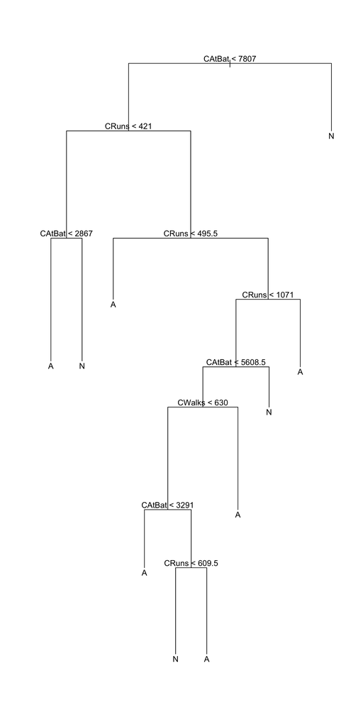

```r
library(tree)
t1 <- tree(League ~ ., data = hit_rforest)
plot(t1)
text(t1, pretty = 0)
```

## Subsequent splits

- Each split takes a new random sample (without replacement) of \(m\) predictors as candiates.
- This can be done more succinctly with `randomForest()` in `library(randomForest())`.

## Random Forests: tree 2

Create a new bootstrap a data set.

```r
boot_ind <- sample(1:nrow(Hitters), replace = TRUE)
hit_boot <- Hitters[boot_ind, ]
```

## A random candidate set

```r
m <- sqrt(ncol(hit_boot))
names(hit_boot)
```

```
##  [1] "AtBat"     "Hits"      "HmRun"     "Runs"      "RBI"
##  [6] "Walks"     "Years"     "CAtBat"    "CHits"     "CHmRun"
## [11] "CRuns"     "CRBI"      "CWalks"    "League"    "Division"
## [16] "PutOuts"   "Assists"   "Errors"    "Salary"    "NewLeague"
```

```r
rforest_ind <- sample(1:ncol(hit_boot), size = m, replace = FALSE)
rforest_ind
```

```
## [1] 15  9 11  3
```

```r
hit_rforest <- hit_boot[ , c(rforest_ind, 14)]
```

## The first random split

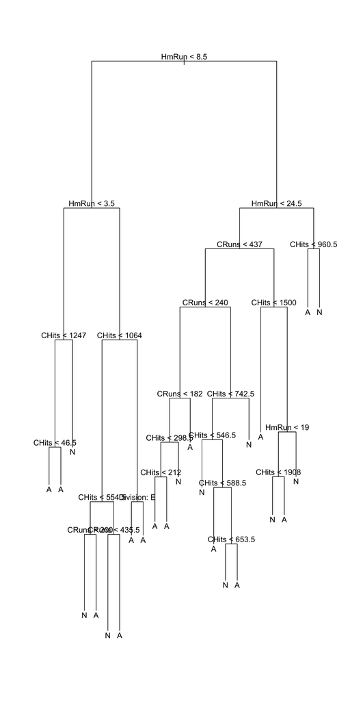

```r
library(tree)
t1 <- tree(League ~ ., data = hit_rforest)
plot(t1)
text(t1, pretty = 0)
```

## Making a final prediction

- Predictor values are plugged into each random tree to make a prediction.
- Final prediction is made by majority vote (classification) or averaging (regression).

## Boosting

## Consider the ant and the bee

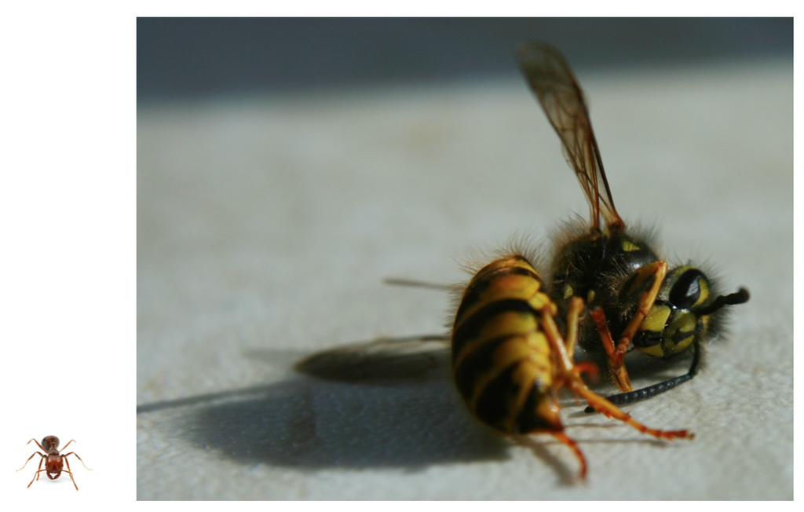

## Consider the ant and the bee

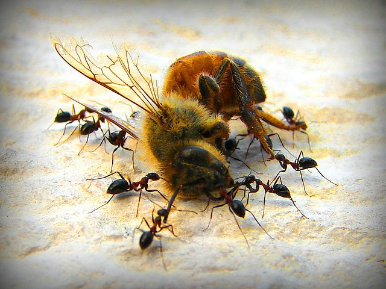

… but combine many complementary weak components, and you get something that's very powerful.

## Boosting

A very general statistical technique that builds up a sequence of weak complementary learners into a boosted learner that is strong.

Note: there is no bootstrapping needed.

## Growing a weak tree

Back to the regression setting…

```r
t2 <- tree(Salary ~ ., data = Hitters)
```

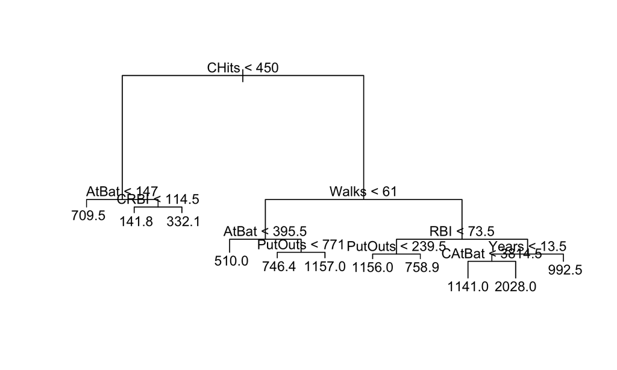

## Growing a weak tree

Let's say we want each weak tree to contain only one split \(d = 1\).

```r
weak1 <- prune.tree(t2, best = 2)
```

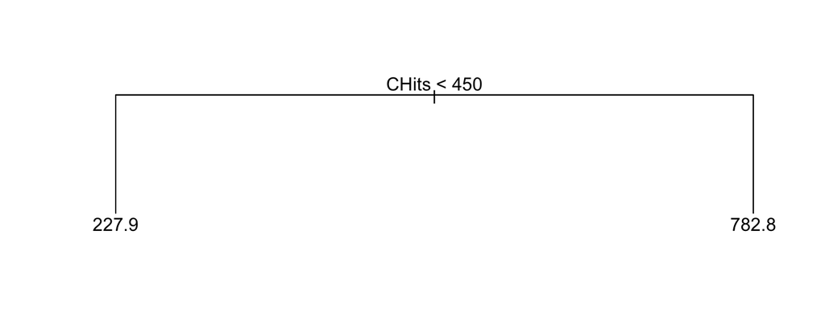

## Finding a complement

How can we figure out where this weak learner failed to explain the data well?

**Residuals**: \(r_i = y_i - \hat{y}_i\)

```r
Hitters$Salary[5:8]
```

```
## [1]  91.5 750.0  70.0 100.0
```

```r
predict(weak1, newdata = Hitters)[5:8]
```

```
## -Andres Galarraga  -Alfredo Griffin        -Al Newman  -Argenis Salazar
##          227.8547          782.8048          227.8547          227.8547
```

```r
Hitters$Salary[5:8] - predict(weak1, newdata = Hitters)[5:8]
```

```
## -Andres Galarraga  -Alfredo Griffin        -Al Newman  -Argenis Salazar
##        -136.35470         -32.80484        -157.85470        -127.85470
```

## Growing a new weak tree

```r
r1 <- Hitters
r1$Salary <- Hitters$Salary - predict(weak1, newdata = Hitters)
t3 <- tree(Salary ~ ., data = r1)
weak2 <- prune.tree(t3, best = 2)
```

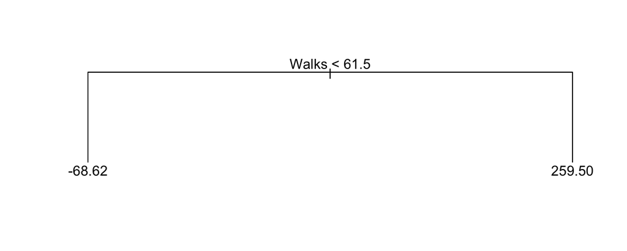

## And so on…

- Continue process of fitting simple trees (weak learners) to the residuals from the previous model.
- Stop after you've made a total of \(B\) trees.
- Final boosted prediction:

\[ \hat{f}(x) = \frac{1}{B} \sum_{b = 1}^B \hat{f}^b(x)\]

well, that's close, but we can be a bit more flexible.